# Impact of Severe Weather Events on Economy and Health in the US

Cleitus

Thursday, December 18, 2014

## 1. Introduction

Storms and other severe weather events can cause both public health and economic problems for communities and municipalities. Many severe events can result in fatalities, injuries, and property damage, and preventing such outcomes to the extent possible is a key concern.

This project involves exploring the U.S. National Oceanic and Atmospheric Administration’s (NOAA) storm database. This database tracks characteristics of major storms and weather events in the United States, including when and where they occur, as well as estimates of any fatalities, injuries, and property damage.

## 2. Synopsis

Over 50 years of recorded events, enabled us enough information on large variety of event types. After some reflexion, the real problem comes down to what question are we asking, in other terms, what situation are we in:  
- Planning for long term projects  
- Managing imminent events

Those two questions require 2 different approaches, an overall approach (sum over all years), and an average one (mean value for each event type).

## 3. Data Processing

The analysis was performed on [Storm Events Database](http://www.ncdc.noaa.gov/stormevents/ftp.jsp), provided by the [National Climatic Data Center](http://www.ncdc.noaa.gov/). The data for this paper come in the form of a comma-separated-value file compressed via the bzip2 algorithm to reduce its size. You can download the file [here](https://d396qusza40orc.cloudfront.net/repdata%2Fdata%2FStormData.csv.bz2).There is also some documentation of the database available. In this [Codebook](https://d396qusza40orc.cloudfront.net/repdata%2Fpeer2_doc%2Fpd01016005curr.pdf) you can find out how some of the variables are constructed/defined. You can also check out the National Climatic Data Center Storm Events [FAQ](https://d396qusza40orc.cloudfront.net/repdata%2Fpeer2_doc%2FNCDC%20Storm%20Events-FAQ%20Page.pdf).

First, download and read the data into a data frame called `data`.

```r
# Load necessary library
library(ggplot2)
library(dplyr)
library(gridExtra)
# Loading data
if (!file.exists("repdata_data_StormData.csv.bz2")) {
  fileURL <- 'https://d396qusza40orc.cloudfront.net/repdata%2Fdata%2FStormData.csv.bz2'
  download.file(fileURL, destfile='repdata_data_StormData.csv.bz2', method = 'curl')
}
data <- read.csv(bzfile('repdata_data_StormData.csv.bz2'),header=TRUE, stringsAsFactors = TRUE)
str(data)
```

```
## 'data.frame':    902297 obs. of  37 variables:
##  $ STATE__   : num  1 1 1 1 1 1 1 1 1 1 ...
##  $ BGN_DATE  : Factor w/ 16335 levels "1/1/1966 0:00:00",..: 6523 6523 4242 11116 2224 2224 2260 383 3980 3980 ...
##  $ BGN_TIME  : Factor w/ 3608 levels "00:00:00 AM",..: 272 287 2705 1683 2584 3186 242 1683 3186 3186 ...
##  $ TIME_ZONE : Factor w/ 22 levels "ADT","AKS","AST",..: 7 7 7 7 7 7 7 7 7 7 ...
##  $ COUNTY    : num  97 3 57 89 43 77 9 123 125 57 ...
##  $ COUNTYNAME: Factor w/ 29601 levels "","5NM E OF MACKINAC BRIDGE TO PRESQUE ISLE LT MI",..: 13513 1873 4598 10592 4372 10094 1973 23873 24418 4598 ...
##  $ STATE     : Factor w/ 72 levels "AK","AL","AM",..: 2 2 2 2 2 2 2 2 2 2 ...
##  $ EVTYPE    : Factor w/ 985 levels "   HIGH SURF ADVISORY",..: 834 834 834 834 834 834 834 834 834 834 ...
##  $ BGN_RANGE : num  0 0 0 0 0 0 0 0 0 0 ...
##  $ BGN_AZI   : Factor w/ 35 levels "","  N"," NW",..: 1 1 1 1 1 1 1 1 1 1 ...
##  $ BGN_LOCATI: Factor w/ 54429 levels "","- 1 N Albion",..: 1 1 1 1 1 1 1 1 1 1 ...
##  $ END_DATE  : Factor w/ 6663 levels "","1/1/1993 0:00:00",..: 1 1 1 1 1 1 1 1 1 1 ...
##  $ END_TIME  : Factor w/ 3647 levels ""," 0900CST",..: 1 1 1 1 1 1 1 1 1 1 ...
##  $ COUNTY_END: num  0 0 0 0 0 0 0 0 0 0 ...
```

[output cut: 23 more lines]

This is a huge amount of data, and a big part of it useless in our investigation, So let’s do some cleansing. I’m only keeping the 7 variables that are essential to our study.

```r
# Getting rid of excess data
data <- data %>%
  select(EVTYPE, FATALITIES, INJURIES, PROPDMG, PROPDMGEXP, CROPDMG, CROPDMGEXP)
```

```r
# Array of documented events
Events <- c("ASTRONOMICAL LOW TIDE","AVALANCHE","BLIZZARD","COASTAL FLOOD","COLD/WIND CHILL","DEBRIS FLOW","DENSE FOG",
            "DENSE SMOKE","DROUGHT","DUST DEVIL","DUST STORM","EXCESSIVE HEAT","EXTREME COLD/WIND CHILL","FLASH FLOOD",
            "FLOOD","FROST/FREEZE","FUNNEL CLOUD","FREEZING FOG","HAIL","HEAT","HEAVY RAIN","HEAVY SNOW","HIGH SURF",
            "HIGH WIND","HURRICANE (TYPHOON)","ICE STORM","LAKE-EFFECT SNOW","LAKESHORE FLOOD","LIGHTNING","MARINE HAIL",
            "MARINE HIGH WIND","MARINE STRONG WIND","MARINE THUNDERSTORM WIND","RIP CURRENT","SEICHE","SLEET","STORM SURGE/TIDE",
            "STRONG WIND","THUNDERSTORM WIND","TORNADO","TROPICAL DEPRESSION","TROPICAL STORM","TSUNAMI","VOLCANIC ASH",
            "WATERSPOUT","WILDFIRE","WINTER STORM","WINTER WEATHER")

#Filter the events, keep only those documented and have health or financial impact.
data <- filter(data, toupper(EVTYPE) %in% Events,
               ((!is.na(F) & F > 0) | (!is.na(PROPDMG) & PROPDMG > 0)))

str(data)
```

```
## 'data.frame':    161517 obs. of  7 variables:
##  $ EVTYPE    : Factor w/ 985 levels "   HIGH SURF ADVISORY",..: 834 834 834 834 834 834 834 834 834 834 ...
##  $ FATALITIES: num  0 0 0 0 0 0 0 0 1 0 ...
##  $ INJURIES  : num  15 0 2 2 2 6 1 0 14 0 ...
##  $ PROPDMG   : num  25 2.5 25 2.5 2.5 2.5 2.5 2.5 25 25 ...
##  $ PROPDMGEXP: Factor w/ 19 levels "","-","?","+",..: 17 17 17 17 17 17 17 17 17 17 ...
##  $ CROPDMG   : num  0 0 0 0 0 0 0 0 0 0 ...
##  $ CROPDMGEXP: Factor w/ 9 levels "","?","0","2",..: 1 1 1 1 1 1 1 1 1 1 ...
```

More work needs to be done on the exponant columns, for instance:

```r
data$PROPDMGEXP<-toupper(data$PROPDMGEXP)
data$CROPDMGEXP<-toupper(data$CROPDMGEXP)
unique(data$PROPDMGEXP)
```

```
##  [1] "K" "M" ""  "B" "+" "0" "5" "6" "4" "H" "2" "7" "3" "-"
```

```r
unique(data$CROPDMGEXP)
```

```
## [1] ""  "M" "K" "B" "?" "0"
```

I’m gonna get a unique column for both property damage and crop damage by “getting rid” of the exponent columns. Here is one way to do it.

```r
exponent <- function(x) {
  switch(x, "B"=1e+09, "M"=1e+06, "K"=1e+03, "H"=1e+02,
         "0"=0, "1"=1,"2"=2,"3"=3,"4"=4,"5"=5,"6"=6,"7"=7, 0)
}
data <- data %>%
  mutate(PROPDMG = PROPDMG * sapply(PROPDMGEXP, exponent),
         CROPDMG = CROPDMG * sapply(CROPDMGEXP, exponent)) %>%
  select(EVTYPE, FATALITIES, INJURIES, PROPDMG, CROPDMG)

str(data)
```

[output not shown]

Last step, get the **total** casualties/damages for each event type (this is useful for long term planning), and the **average** casualty/damage per event type (this is particularly useful in case of managing ongoing events).

```r
mean_data <- aggregate(. ~ EVTYPE, data = data, mean)
data      <- aggregate(. ~ EVTYPE, data = data, sum)

#Final shape of the data frame that's gonna be used to plot the results
str(data)
```

[output not shown]

```r
str(mean_data)
```

```
## 'data.frame':    488 obs. of  5 variables:
##  $ EVTYPE    : Factor w/ 985 levels "   HIGH SURF ADVISORY",..: 1 3 5 6 9 14 15 16 17 18 ...
##  $ FATALITIES: num  0 0 0 0 0 0 0 0 0 1 ...
##  $ INJURIES  : num  0 0 0 0 0 0 0 0 0 0 ...
##  $ PROPDMG   : num  200000 50000 4050000 8000 5000 ...
##  $ CROPDMG   : num  0 0 0 0 0 ...
```

Finally seperate the data related to health from that which is related to economy.

```r
health <- data %>%
  select(EVTYPE, FATALITIES, INJURIES)%>%
  arrange(desc(FATALITIES))

econ <- data %>%
  select(EVTYPE, PROPDMG, CROPDMG)%>%
  arrange(desc(PROPDMG))

m_health <- mean_data %>%
  select(EVTYPE, FATALITIES, INJURIES)%>%
  arrange(desc(FATALITIES))

m_econ <- mean_data %>%
  select(EVTYPE, PROPDMG, CROPDMG)%>%
  arrange(desc(PROPDMG))

m_econ$damage     <- m_econ$PROPDMG + m_econ$CROPDMG
m_health$casualty <- m_health$FATALITIES + m_health$INJURIES
```

## 4. Results

#### Overall impact on health

From a health percpective, overall between 1950 and 2011:

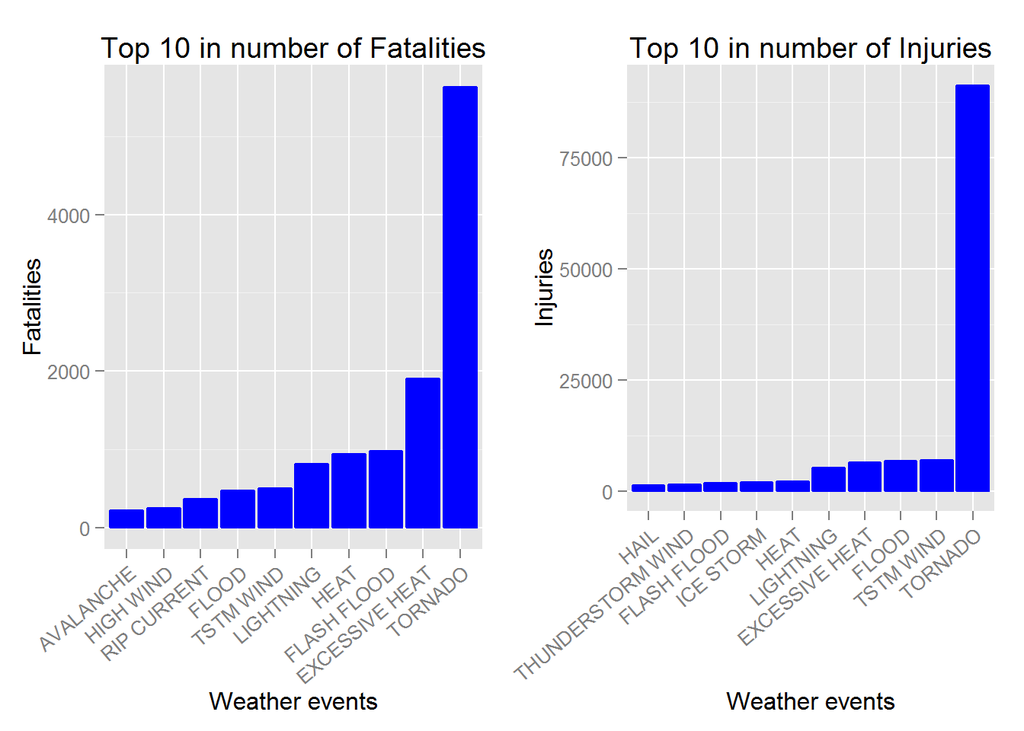

```r
p1 <- ggplot(head(health,10), aes(x=reorder(EVTYPE, FATALITIES), y=FATALITIES))
p2 <- ggplot(head(arrange(health, desc(INJURIES)),10),
             aes(x=reorder(EVTYPE, INJURIES), y=INJURIES))

p1 <- p1 + geom_bar(stat="identity", colour="blue", fill="blue")+
  theme(axis.text.x=element_text(angle=-320, hjust = 1))+
  labs(x="Weather events", y="Fatalities",
       title="Top 10 in number of Fatalities")

p2 <- p2 + geom_bar(stat="identity", colour="blue", fill="blue")+
  theme(axis.text.x=element_text(angle=-320, hjust = 1))+
  labs(x="Weather events", y="Injuries",
       title="Top 10 in number of Injuries")

grid.arrange(p1, p2, ncol = 2)
```

#### Overall impact on the economy

From a economic point of vue, overall between 1950 and 2011:

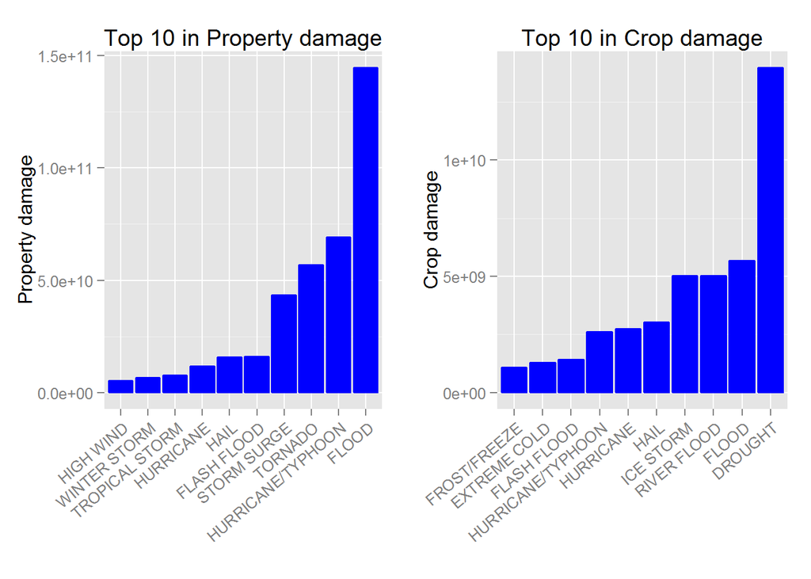

```r
p1 <- ggplot(head(econ,10), aes(x=reorder(EVTYPE, PROPDMG), y=PROPDMG))
p2 <- ggplot(head(arrange(econ, desc(CROPDMG)),10),
             aes(x=reorder(EVTYPE, CROPDMG), y=CROPDMG))

p1 <- p1 + geom_bar(stat="identity", colour="blue", fill="blue")+
  theme(axis.text.x=element_text(angle =-320, hjust = 1))+
  labs(x="", y="Property damage",
       title="Top 10 in Property damage")

p2 <- p2 + geom_bar(stat="identity", colour="blue", fill="blue")+
  theme(axis.text.x=element_text(angle=-320, hjust = 1))+
  labs(x="", y="Crop damage",
       title="Top 10 in Crop damage")

grid.arrange(p1, p2, ncol = 2)
```

#### Average impact on health/economy per occurence

Now for a look on the top 10 events in each category, but this time in the term of average damage of an event if it occures:

[figure not shown]

```r
p1 <- ggplot(head(m_health,10), aes(x=reorder(EVTYPE, casualty), y=casualty))
#p2 <- ggplot(head(arrange(m_health, desc(INJURIES)),10),
#             aes(x=reorder(EVTYPE, INJURIES), y=INJURIES))
p3 <- ggplot(head(m_econ,10), aes(x=reorder(EVTYPE, damage), y=damage))
#p4 <- ggplot(head(arrange(econ, desc(CROPDMG)),10),
#             aes(x=reorder(EVTYPE, CROPDMG), y=CROPDMG))

p1 <- p1 + geom_bar(stat="identity", colour="blue", fill="blue")+
  theme(axis.text.x=element_text(angle=-320, hjust = 1))+
  labs(x="", y="Fatalities + Injuries", title="Avg nbr of Casualties in occurence")
#p2 <- p2 + geom_bar(stat="identity", colour="blue", fill="blue")+
#  theme(axis.text.x=element_text(angle=-320, hjust = 1))+
#  labs(x="", y="Injuries", title="Top 10 in number of Injuries")
p3 <- p3 + geom_bar(stat="identity", colour="blue", fill="blue")+
  theme(axis.text.x=element_text(angle=-320, hjust = 1))+
  labs(x="", y="Property + crop damage", title="Avg damage in occurence")
#p4 <- p4 + geom_bar(stat="identity", colour="blue", fill="blue")+
#  theme(axis.text.x=element_text(angle=-320, hjust = 1))+
#  labs(x="", y="Crop damage", title="Top 10 in Crop damage")

grid.arrange(p1, p3, ncol = 2)
```